# Group Lab 1

#### Statistical Analysis and Discussion

We ran three comparison of means tests (a Welch’s two-sample t-test, a Welch’s two-sample t-test on logged data, and a non-parametric Wilcoxon test) for each one of our four hypotheses.

##### Methane levels (ug/L) near fracking sites vs. Methane levels (ug/L) far from fracking sites for ALL observations.

For the first comparison we suspected that methane levels near fracking sites would be higher than methane levels far from fracking sites (H0: mu_near - mu_far <= 0; Ha: mu_near - mu_far > 0), so we performed a two-sample, one-sided t-test. The Welch’s t-test provided no evidence to suggest that wells near fracking sites have higher methane levels than wells further from fracking sites (t = -0.45603, df = 413.32, p-value = 0.3243). However, a Welch’s t-test with logged data provided strong evidence (p<0.01) that methane levels near fracking sites were higher than methane levels far from fracking sites (t = -4.9723, df = 520.92, p-value = 4.499e-07). Our results from the Shapiro-Wilk normality tests for data on near (p-value < 2.2e-16) and far wells (p-value < 2.2e-16) and logged data for near (p-value = 9.473e-14) and far wells (p-value < 2.2e-16), indicate that our samples follow a non-normal distribution. Given our large sample sizes (n= 322 and n= 1,379), however, the results of the two sample Welch’s t-test are robust to this violation of the assumption of normality. We also ran a non-parametric Wilcoxon rank sum test. Our results (W = 171369, p-value = 8.21e-11) suggest that the samples were likely not derived from the same population. Finally, we estimated the multiplicative factor of the medians as 0.4021 ug/L methane, meaning the median methane level (ug/L) in the wells far from fracking sites is estimated to be 40.2% of the median methane level (ug/L) in wells near fracking sites. We are 95% confident that the interval (0 ug/L, 0.5438 ug/L) includes the true multiplicative factor of the medians.

##### Methane levels near fracking sites vs. Methane levels far from fracking sites for valley observations .

For the second comparison, we used a two-sample, one-sided t-test (H0: mu_near - mu_far <= 0; Ha: mu_near - mu_far > 0). The Welch’s t-test (t = -0.097458, df = 267.29, p-value = 0.4612) provided no evidence to suggest that wells near fracking sites have higher methane levels than wells further from fracking sites in valley observations. The results of our Welch’s t-test test (t = -1.8711, df = 377.96, p-value = 0.03105) using logged methane levels provide moderate evidence (p < 0.05) that valley methane levels near fracking sites are greater than valley methane levels far from fracking sites. Given the skew using the original data, the t-test using logged methane levels is likely more reliable. In the Shapiro-Wilks test for both the original (near: p-value < 2.2e-16, far: p-value < 2.2e-16) and logged data (near: p-value < 1.531e-11, far: p-value 2.2e-16), we rejected the null hypothesis, meaning our samples were not pulled from a normally distributed population. The results of our nonparametric Wilcoxon rank sum test (W = 55564, p-value = 0.0007267) suggest that the population distribution of methane levels near valley fracking sites are not the same as valley methane levels far from fracking sites. The multiplicative factor of the medians for valley sites is 0.6178 ug/L. This means that the median methane level (ug/L) in the farther wells is estimated to be 61.8% of the median methane level (ug/L) in wells near fracking sites for valley sites. We are 95% confident that the interval (0 ug/L, 0.9444 ug/L) includes the true multiplicative factor of the medians.

#### Conclusion

Typically the Welch’s t-test assumes a normal distribution. However, as the sample size in the two samples gets large, the t-test can still be valid even when the groups do not follow the normal distribution. Meeting the assumptions of the t-tests are more critical when sample sizes are small, skewness differs, and normality assumptions are not met. Despite non-normal distributions of the data, the robustness of the two-sample test, the samples shewing in similar directions, and the sample sizes greater than 40 (Tables 1-4) suggest that the Welch’s t-tests of the log data are reliable. Another concern is that the results of our Wilcoxon rank sum tests suggest that the populations being compared have different shapes. Moreover, while we assume independence of observations between or within groups, spatial autocorrelation should be something to consider.

Molofsky et al. (2013)’s analysis failed to address these population distribution issues. Molofsky et al. (2013) made statistical inferences about the methane concentrations only using Wilcoxon Rank Sum. However, our results suggest that the near vs far groups for all the data, valley sites and upland sites do not have similarly shaped distributions. Therefore, the Wilcoxon Rank Sum test should only be used to talk about differences between the populations in this scenario – not to compare means of those populations. Another shortcoming of the Molofsky et. al article is that they don’t consider logged data and that they do not address the censored observations.

Molofsky et al. (2013) implies that the methane levels are correlated with topography (e.g., valley and uplands) - rather than proximity to fracking sites. However, our results suggest that fracking activities likely are associated with higher methane concentrations, which would have a negative impact on water quality. The data was randomly sampled, so the results we find are generalizable to methane levels in drinking water across Susquehanna County, Pennsylvania. If this is the case, policymakers should take action to protect drinking water from fracking activities in order to protect public health.

Reference: Data were downloaded from the supplemental material associated with the article by: Molofsky, L.J., Connor, J.A., Wylie, A.S., Wagner, T. and S.K. Farhat. (2013). Evaluation of Methane Sources in Groundwater in Northeastern Pennsylvania. Groundwater, 51(3): 333-349.

## Annex I: Descriptive Statistics

#### *Methane levels near fracking sites vs. Methane levels far from fracking sites for ALL observations*

Table 1. Summary Statistics of Methane Levels, By Proximity to Fracking Wells

ug/L methane in well water

| proximity | Observations | Median | Mean | Minimum | Maximum | SD | Skewness |
| --- | --- | --- | --- | --- | --- | --- | --- |
| Far | 1,379 | 0.600 | 684.3 | 0.0500 | 39,000 | 3,133 | 6.230 |
| Near | 322 | 5.900 | 795.0 | 0.0780 | 43,000 | 4,087 | 6.467 |

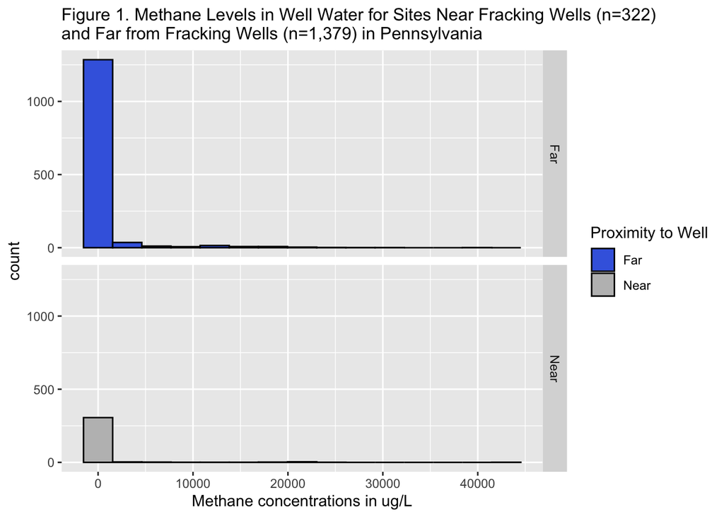

#### *Methane levels near fracking sites vs. Methane levels far from fracking sites for valley observations*

Table 2. Summary Statistics of Methane Levels for Far and Near Valley Sites

Methane measured in ug/L

| proximity | Observations | Mean | Median | Minimum | Maximum | SD | Skewness |
| --- | --- | --- | --- | --- | --- | --- | --- |
| Far | 670 | 1,186 | 1.30 | 0.0870 | 39,000 | 4,059 | 4.510 |
| Near | 195 | 1,226 | 19.00 | 0.0780 | 43,000 | 5,172 | 5.020 |

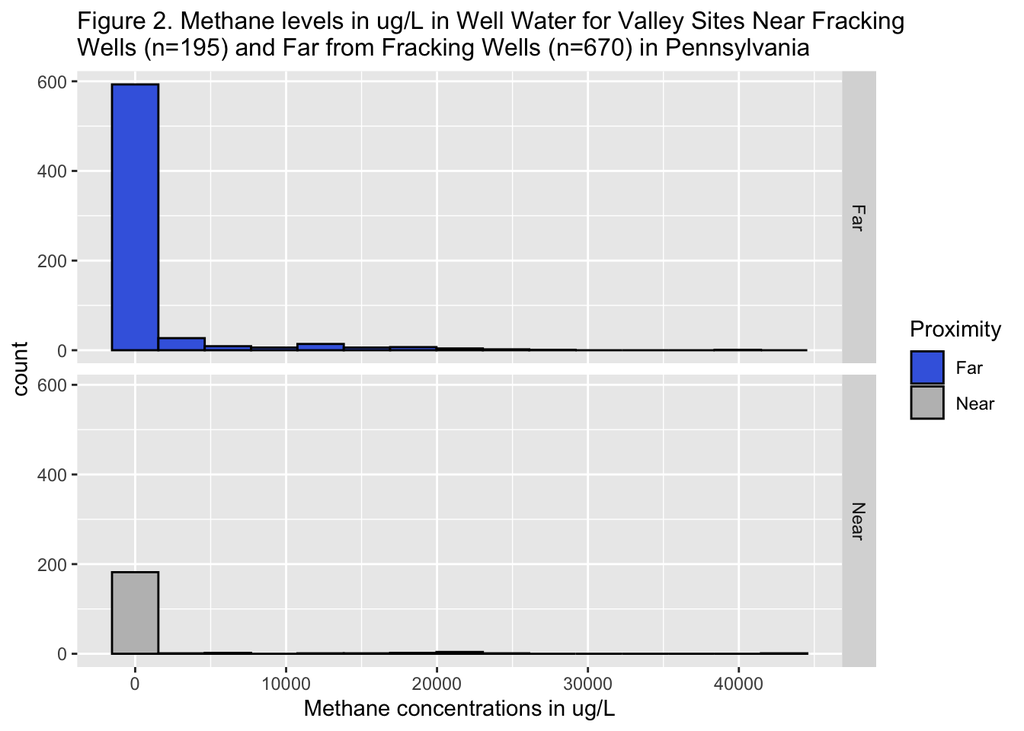

#### *Methane levels near fracking sites vs. Methane levels far from fracking sites for upland observations*

Table 3. Summary Statistics of Methane Levels in Near and Far Upland

methane measured in ug/L

| Proximity | Observations | Mean | Median | Minimum | Maximum | SD | Skewness |
| --- | --- | --- | --- | --- | --- | --- | --- |
| Far | 709 | 209.7 | 0.400 | 0.0500 | 32,000 | 1,753 | 12.80 |
| Near | 127 | 133.9 | 1.400 | 0.1000 | 8,300 | 799 | 8.96 |

[figure not shown]

#### *Methane levels in the valley vs. Methane levels in the upland*

Table 4. Summary Statistics of Methane Levels for Upland and Valley Sites

Methane measured in ug/L

| location | Observations | Mean | Median | Minimum | Maximum | SD | Skewness |
| --- | --- | --- | --- | --- | --- | --- | --- |
| Upland | 836 | 198 | 0.470 | 0.0500 | 32,000 | 1,644 | 13.33 |
| Valley | 865 | 1,195 | 1.800 | 0.0780 | 43,000 | 4,332 | 4.79 |

[figure not shown]

## Annex 2: Comparison of Means Tests

#### *Methane levels near fracking sites vs. Methane levels far from fracking sites for ALL observations*

*Welch’s t-test on original data*

```
##
##  Welch Two Sample t-test
##
## data:  methane by proximity
## t = -0.45603, df = 413.32, p-value = 0.3243
## alternative hypothesis: true difference in means is less than 0
## 95 percent confidence interval:
##      -Inf 289.6408
## sample estimates:
##  mean in group Far mean in group Near
##           684.2574           795.0171
```

*Test for normality on original data*

```
##
##  Shapiro-Wilk normality test
##
## data:  near_fracking_df$methane
## W = 0.19548, p-value < 2.2e-16
```

```
##
##  Shapiro-Wilk normality test
##
## data:  far_fracking_df$methane
## W = 0.22984, p-value < 2.2e-16
```

*Histogram on logged data*

```
##   ID methane dl location proximity log_methane
## 1  1 2.6e+01  1   Valley       Far    3.258097
## 2  2 1.7e+04  0   Valley       Far    9.740969
## 3  3 2.6e+01  1   Upland       Far    3.258097
## 4  4 2.6e+01  1   Upland       Far    3.258097
## 5  5 1.1e-01  0   Upland      Near   -2.207275
## 6  6 1.1e-01  0   Valley       Far   -2.207275
```

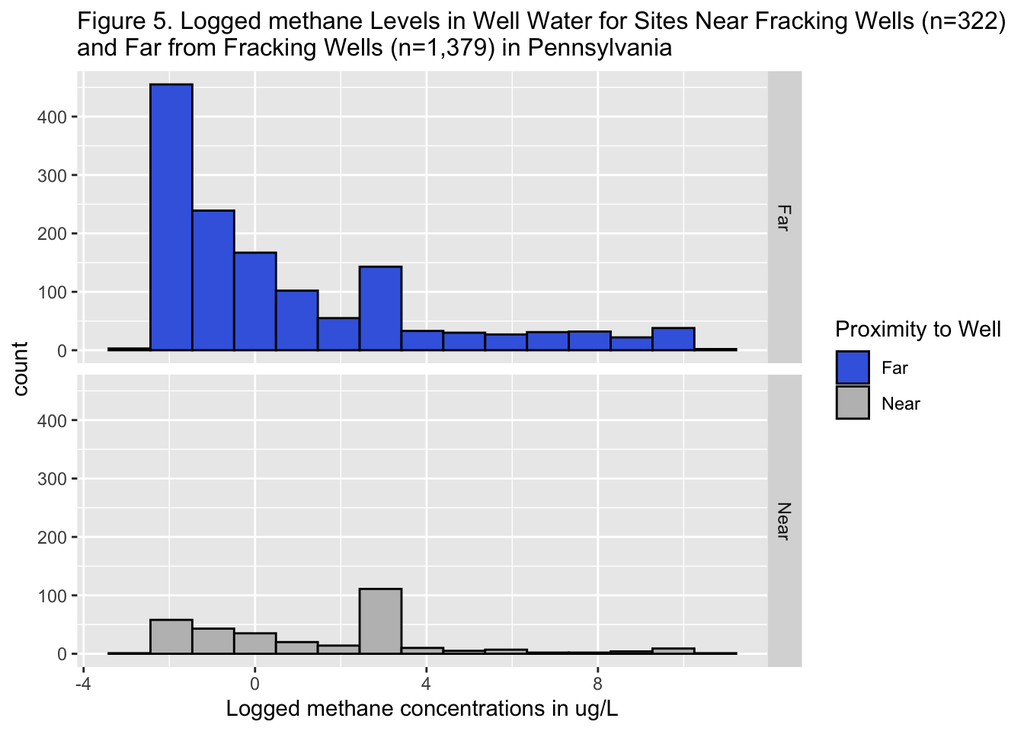

*Shapiro-Wilk test on logged data*

```
##
##  Shapiro-Wilk normality test
##
## data:  near_fracking_df$log_methane
## W = 0.89986, p-value = 9.473e-14
```

```
##
##  Shapiro-Wilk normality test
##
## data:  far_fracking_df$log_methane
## W = 0.83356, p-value < 2.2e-16
```

*Welch’s t-test on logged data*

```
##
##  Welch Two Sample t-test
##
## data:  log_methane by proximity
## t = -4.9723, df = 520.92, p-value = 4.499e-07
## alternative hypothesis: true difference in means is less than 0
## 95 percent confidence interval:
##        -Inf -0.6091616
## sample estimates:
##  mean in group Far mean in group Near
##           0.689035           1.600130
```

*Multiplicative factor of the median*

```
## The multiplicative factor of the medians for all sites (far - near) is 0.4021 ug/L
```

*Confidence interval the logged data*

```
## The confidence interval for all sites for far and near is 0 to 0.5438 ug/L
```

*Non-parametric test = Wilcox test*

```
##
##  Wilcoxon rank sum test with continuity correction
##
## data:  methane by proximity
## W = 171369, p-value = 8.21e-11
## alternative hypothesis: true location shift is less than 0
```

#### *Methane levels near fracking sites vs. Methane levels far from fracking sites for valley observations*

*Welch’s t-test on original data*

```
##
##  Welch Two Sample t-test
##
## data:  methane by proximity
## t = -0.097458, df = 267.29, p-value = 0.4612
## alternative hypothesis: true difference in means is less than 0
## 95 percent confidence interval:
##      -Inf 624.6699
## sample estimates:
##  mean in group Far mean in group Near
##           1186.406           1225.604
```

*Test for normality on original data*

```
##
##  Shapiro-Wilk normality test
##
## data:  valley_fracking_far$methane
## W = 0.33088, p-value < 2.2e-16
```

```
##
##  Shapiro-Wilk normality test
##
## data:  valley_fracking_near$methane
## W = 0.2533, p-value < 2.2e-16
```

*Histogram on logged data*

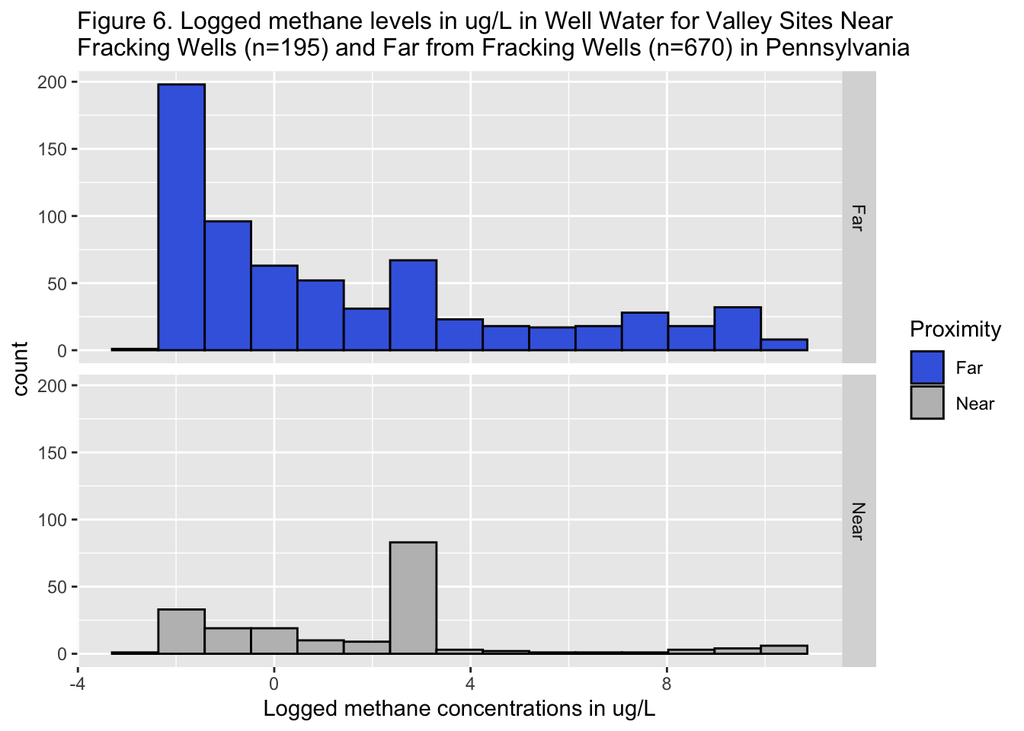

*Shapiro-Wilk test on logged data*

```
##
##  Shapiro-Wilk normality test
##
## data:  valley_fracking_far$log_methane
## W = 0.86535, p-value < 2.2e-16
```

```
##
##  Shapiro-Wilk normality test
##
## data:  valley_fracking_near$log_methane
## W = 0.87657, p-value = 1.531e-11
```

*Welch’s t-test on logged data*

```
##
##  Welch Two Sample t-test
##
## data:  log_methane by proximity
## t = -1.8711, df = 377.96, p-value = 0.03105
## alternative hypothesis: true difference in means is less than 0
## 95 percent confidence interval:
##         -Inf -0.05719201
## sample estimates:
##  mean in group Far mean in group Near
##           1.436479           1.918133
```

*Confidence interval for the logged data*

```
## The confidence interval for valley sites for far and near is 0 to 0.9444 ug/L
```

*multiplicative factor of the medians*

```
## The multiplicative factor of the medians for valley sites (far - near) is 0.6178 ug/L
```

*Non-parametric test = Wilcox test*

```
##
##  Wilcoxon rank sum test with continuity correction
##
## data:  methane by proximity
## W = 55564, p-value = 0.0007267
## alternative hypothesis: true location shift is less than 0
```